# Data Visualization

### Adding lines to points and plots

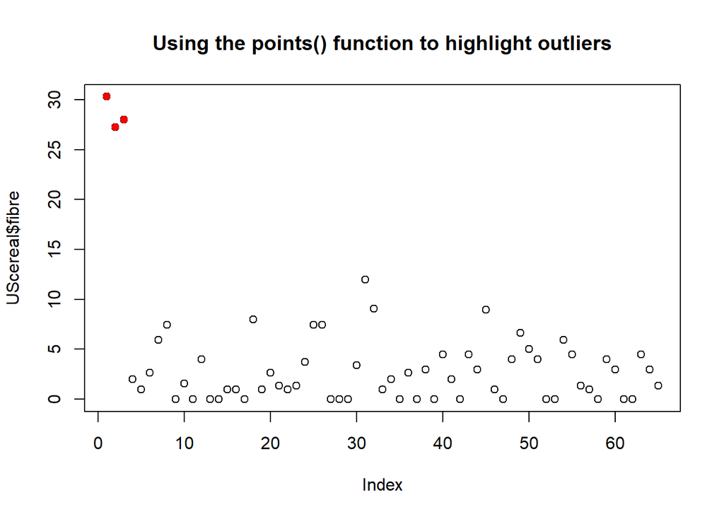

```r
library(MASS)
plot(UScereal$fibre)
index <- which(UScereal$fibre > 20)
points(index, UScereal$fibre[index], pch = 16, col = "red")
title("Using the points() function to highlight outliers")
```

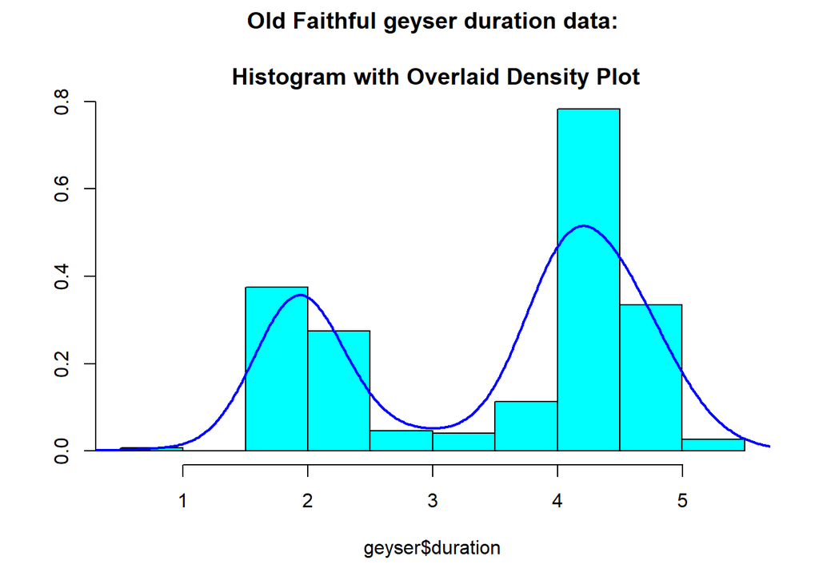

```r
#density line
library(MASS)
truehist(geyser$duration)
lines(density(geyser$duration), lwd = 2, col = "blue")
title("Old Faithful geyser duration data:
      \n Histogram with Overlaid Density Plot")
```

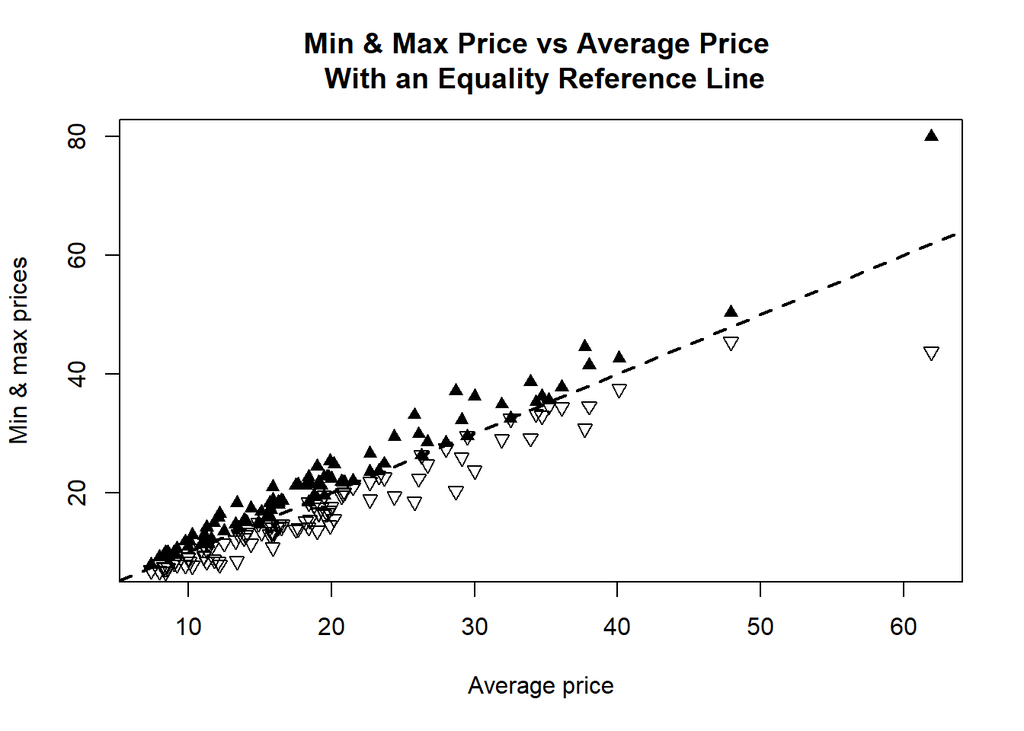

```r
#abline
plot(Cars93$Price, Cars93$Max.Price, pch = 17,
     xlab = "Average price",
     ylab = "Min & max prices")
points(Cars93$Price, Cars93$Min.Price, pch = 6)
abline(a= 0, b = 1, lty = 2, lwd = 2) #equality reference line
title("Min & Max Price vs Average Price \n With an Equality Reference Line")
```

### The lines() function and line types

As noted in Chapter 2, numerical data is often assumed to conform approximately to a Gaussian probability distribution, characterized by the bell curve. One point of this exercise is to show what this bell curve looks like for exactly Gaussian data and the other is to show how the lines() function can be used to add lines to an existing plot.

The curves you are asked to draw here have the same basic shape but differ in their details (specifically, the means and standard deviations of these Gaussian distributions are different). For this reason, it is useful to draw these curves with different line types to help us distinguish them.

Note that line types are set by the lty argument, with the default value lty = 1 specifying solid lines, lty = 2 specifying dashed lines, and lty = 3 specifying dotted lines. Also note that the lwd argument specifies the relative width.

Create a numerical variable x with 200 evenly-spaced values from 0 to 10. Using the dnorm() function, generate a vector gauss1 of Gaussian probability densities for this range of x values, with mean 2 and standard deviation 0.2. Using the dnorm() function, generate a vector gauss2 of Gaussian probability densities for this range of x values, with mean 4 and standard deviation 0.5. Generate a plot of gauss1 vs. x with lines and a y-axis label “Gaussian probability density”. Using the lines() function, add a second dashed line for gauss2 vs. x with relative width 3 (refer to the line type plot to select the lty parameter).

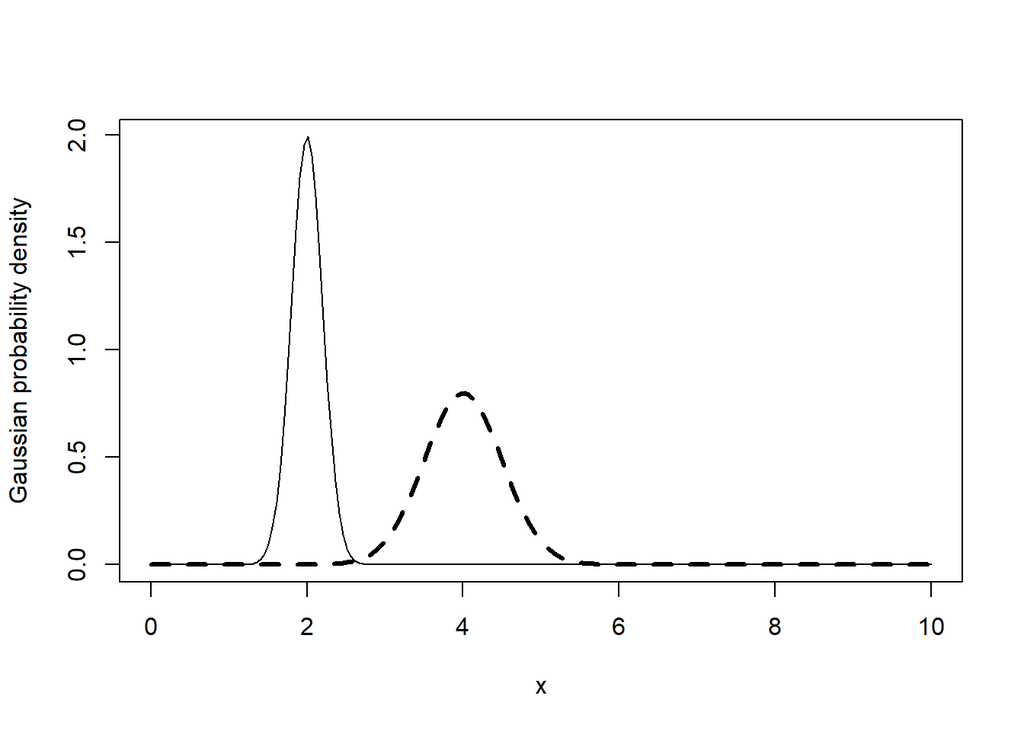

```r
# Create the numerical vector x
x <- seq(0, 10, length = 200)

# Compute the Gaussian density for x with mean 2 and standard deviation 0.2
gauss1 <- dnorm(x, mean = 2, sd = 0.2)

# Compute the Gaussian density with mean 4 and standard deviation 0.5
gauss2 <- dnorm(x, mean = 4, sd = 0.5)

# Plot the first Gaussian density
plot(x, gauss1,
     type = "l",
     ylab = "Gaussian probability density")

# Add lines for the second Gaussian density
lines(x, gauss2, lwd = 3, lty = 2)
```

### The points() function and point types

One advantage of specifying the pch argument locally is that, in a call to functions like plot() or points(), local specification allows us to make pch depend on a variable in our dataset. This provides a simple way of indicating different data subsets with different point shapes or symbols.

This exercise asks you to generate two plots of mpg vs. hp from the mtcars data frame in the datasets package. The first plot specifies the point shapes using numerical values of the pch argument defined by the cyl variable in the mtcars data frame. The second plot illustrates the fact that pch can also be specified as a vector of single characters, causing each point to be drawn as the corresponding character.

Create an empty plot of mpg vs. hp using the type = “n” option from the mtcars data frame, with axis labels “Horsepower” and “Gas mileage”. Using the points() function, add the mpg vs. hp data, with pch specified by the numeric values of cyl. Repeat both of the previous steps, except with pch specified by the character values of cyl.

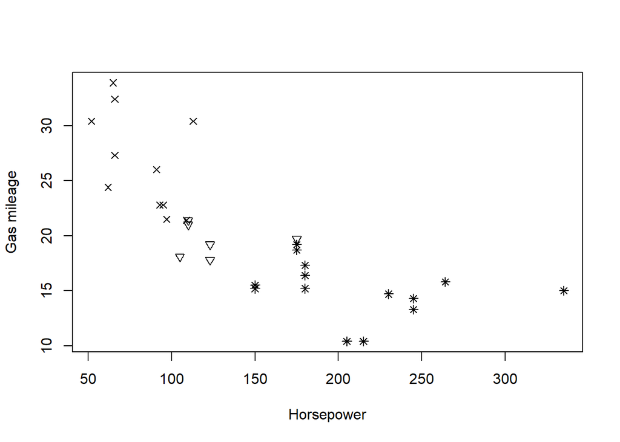

```r
# Create an empty plot using type = "n"
plot(mtcars$hp, mtcars$mpg,
     type = "n",
     xlab = "Horsepower",
     ylab = "Gas mileage")

# Add points with shapes determined by cylinder number
points(mtcars$hp, mtcars$mpg, pch = mtcars$cyl)
```

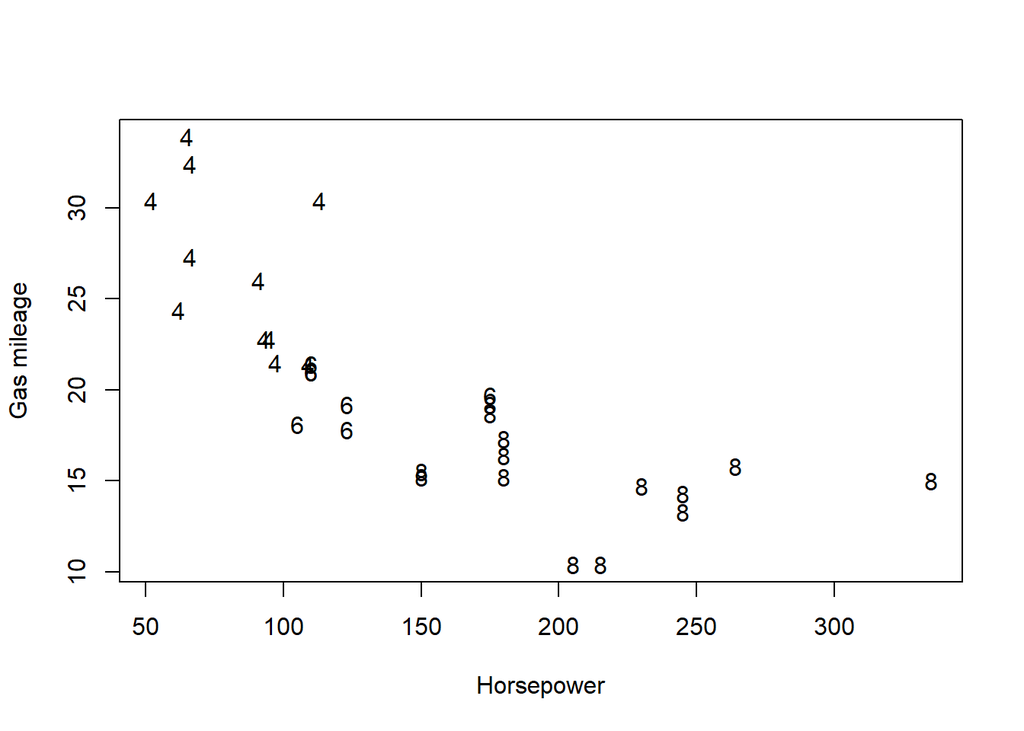

```r
# Create a second empty plot
plot(mtcars$hp, mtcars$mpg,
     type = "n",
     xlab = "Horsepower",
     ylab = "Gas mileage")

# Add points with shapes as cylinder characters
points(mtcars$hp, mtcars$mpg, pch = as.character(mtcars$cyl))
```

### Adding trend lines from linear regression models

The low-level plot function abline() adds a straight line to an existing plot. This line is specified by an intercept parameter a and a slope parameter b, and the simplest way to set these parameters is directly. For example, the command abline(a = 0, b = 1) adds an equality reference line with zero intercept and unit (i.e. 1) slope: points for which y = x fall on this reference line, while points with y > x fall above it, and points with y < x fall below it.

An alternative way of specifying these parameters is through a linear regression model that determines them from data. One common application is to generate a scatterplot of y versus x, then fit a linear model that predicts y from x, and finally call abline() to add this best fit line to the plot.

This exercise asks you to do this for the Gas versus Temp data from the whiteside data frame in the MASS package. The standard R function that fits linear regression models is lm(), which supports the formula interface. Thus, to fit a linear model that predicts y from x in the data frame df, the call would be lm(y ~ x, data = df). This call returns a linear model object, which can then be passed as an argument to the abline() function to draw the desired line on our plot.

Use the lm() function to create linear_model, a linear regression model that predicts Gas from Temp from the whiteside data frame. Generate a scatterplot of Gas vs. Temp. Using the abline() function, add a dashed reference line that shows the predictions of linear_model.

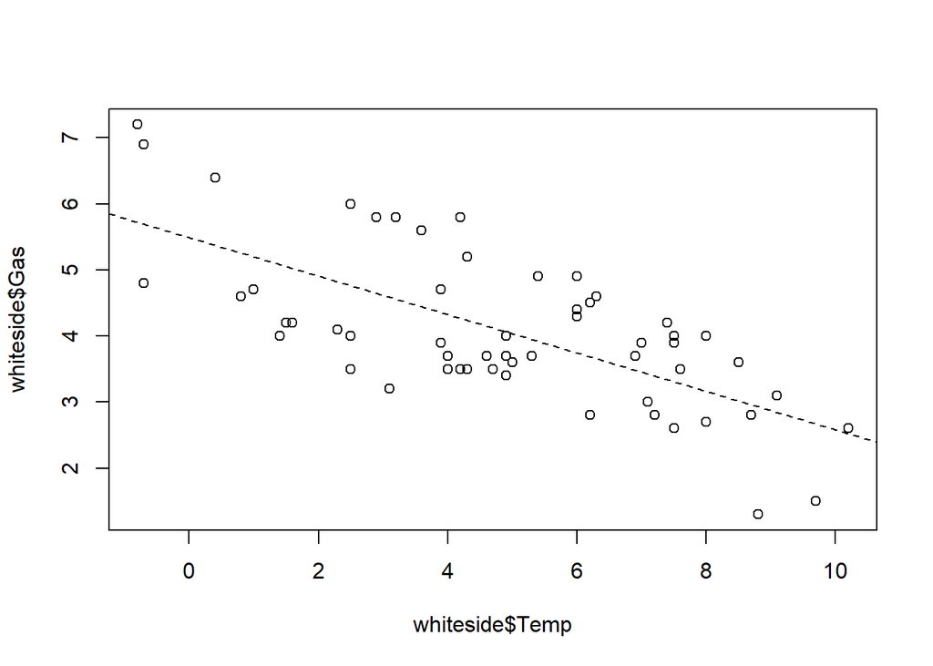

```r
# Build a linear regression model for the whiteside data
linear_model <- lm(Gas ~ Temp, data = whiteside)

# Create a Gas vs. Temp scatterplot from the whiteside data
plot(whiteside$Temp, whiteside$Gas)

# Use abline() to add the linear regression line
abline(linear_model, lty = 2)
```

```r
#Note the line emphasizes the general trend
```

### Adding text to plots

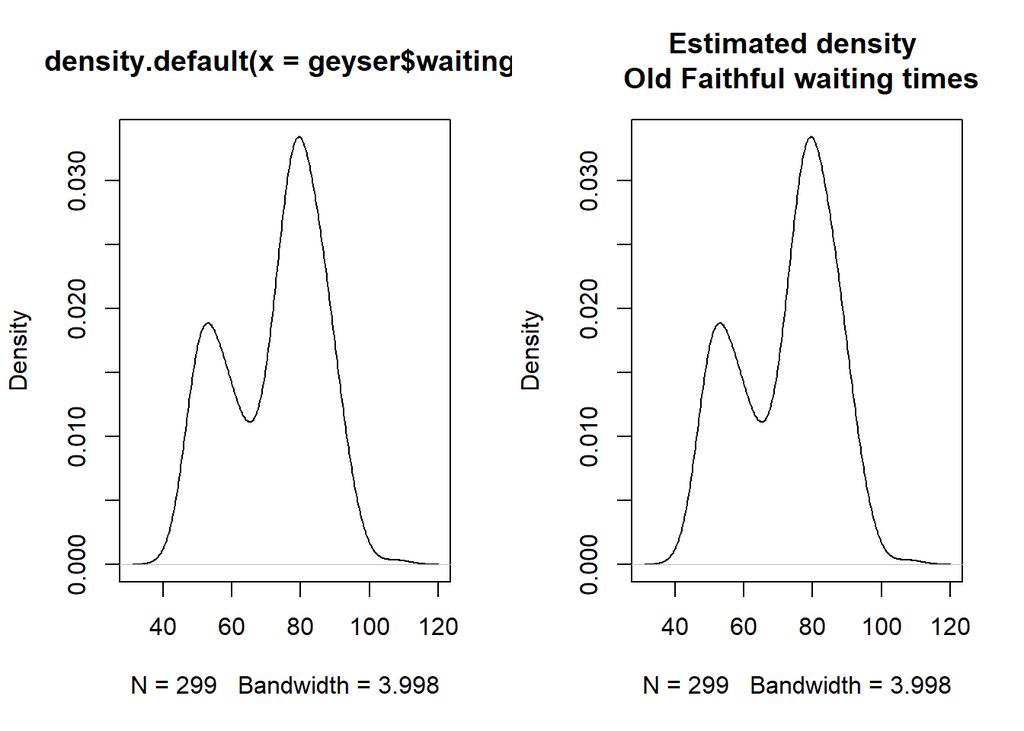

```r
library(MASS)
mfrow(1, 2)
plot(density(geyser$waiting))
plot(density(geyser$waiting),
     main = "Estimated density \n Old Faithful waiting times")
```

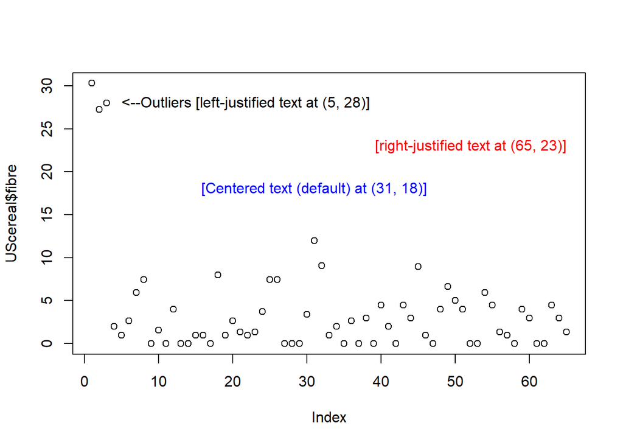

```r
library(MASS)
plot(UScereal$fibre)
text(5, 28, "<--Outliers [left-justified text at (5, 28)]", adj = 0)
text(65, 23, "[right-justified text at (65, 23)]", adj = 1, col = "red")
text(31, 18, "[Centered text (default) at (31, 18)]", col = "blue")
```

```r
#<0 to end text before center, >0 to begin text to right of center
```

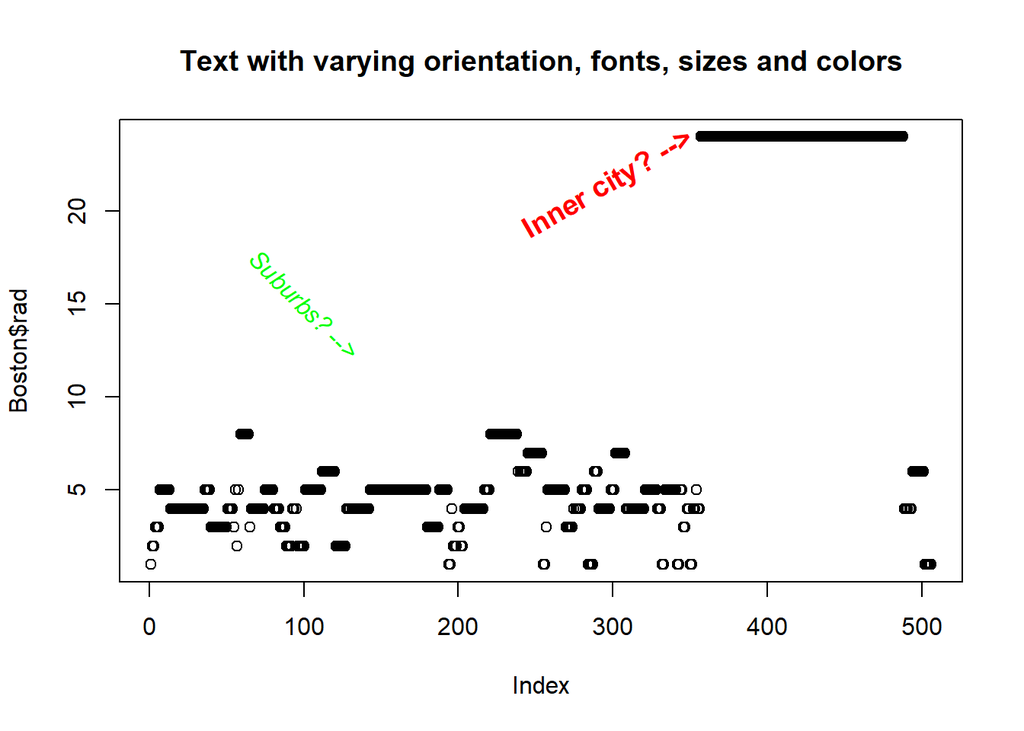

```r
mfrow(1,1)
library(MASS)
plot(Boston$rad)
text(350, 24, adj = 1, "Inner city? -->",
     srt = 30,
     font = 2,
     cex = 1.2,
     col = "red")
text(100, 15, "Suburbs? -->",
     srt = -45,
     font = 3,
     col = "green")
title("Text with varying orientation, fonts, sizes and colors")
```

```r
#srt alters angle of orientation
#cex alters text size as percentage of 1
#col alters text color
#font alters text font, regular, bold, italic, bold/italic, (1,2,3,4)
```

### Using the text() function to label plot features

One of the main uses of the text() function is to add informative labels to a data plot. The text() function takes three arguments:

x, which specifies the value for the x variable, y, which specifies the value for the y variable, and label, which specifies the label for the x-y value pair. This exercise asks you to first create a scatterplot of city gas mileage versus horsepower from the Cars93 data, then identify an interesting subset of the data (i.e. the 3-cylinder cars) and label these points. You will find that assigning a vector to the x, y, and label arguments to text() will result in labeling multiple points at once.

Create a scatterplot of MPG.city vs. Horsepower from the Cars93 data frame, with points represented as solid squares. Recall that the pch value for solid squares is 15. Create the variable index3 using the which() function that identifies all 3-cylinder cars. Label the Make of each 3-cylinder car in the Cars93 data frame using the text() function. Use the adj argument to specify left-justified text in your labels. Use the zoom feature in the Plots window to see this plot more clearly.

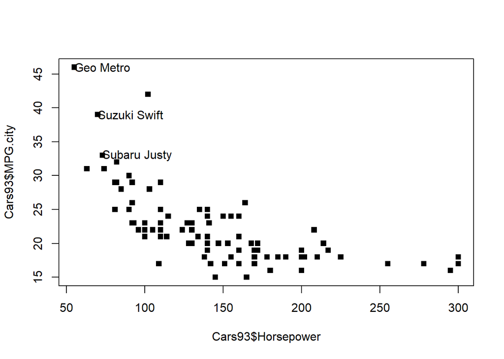

```r
# Create MPG.city vs. Horsepower plot with solid squares
plot(Cars93$Horsepower, Cars93$MPG.city,
     pch = 15)

# Create index3, pointing to 3-cylinder cars
index3 <- which(Cars93$Cylinders == 3)

# Add text giving names of cars next to data points
text(x = Cars93$Horsepower[index3],
     y = Cars93$MPG.city[index3],
     labels = Cars93$Make[index3], adj = 0)
```

### Adjusting text position, size, and font

The previous exercise added explanatory text to a scatterplot. The purpose of this exercise is to improve this plot by modifying the text placement, increasing the text size, and displaying the text in boldface.

It was noted that the adj argument to the text() function determines the horizontal placement of the text and it can take any value between 0 and 1. In fact, this argument can take values outside this range. That is, making this value negative causes the text to start to the right of the specified x position. Similarly, making adj greater than 1 causes the text to end to the left of the x position.

Another useful optional argument for the text() function is cex, which scales the default text size. As a specific example, setting cex = 1.5 increases the text size by 50 percent, relative to the default value. Similarly, specifying cex = 0.8 reduces the text size by 20 percent.

Finally, the third optional parameter used here is font, which can be used to specify one of four text fonts: font = 1 is the default text font (neither italic nor bold), font = 2 specifies bold face text, font = 3 specifies italic text, and font = 4 specifies both bold and italic text.

Create a plot of MPG.city vs. Horsepower from the Cars93 data frame, with data represented as open circles. Construct the variable index3 using the which() function that identifies the row numbers containing all 3-cylinder cars. Use the points() function to overlay solid circles on top of all points in the plot that represent 3-cylinder cars. Use the text() function with the Make variable as before to add labels to the right of the 3-cylinder cars, but now use adj = -0.2 to move the labels further to the right, use the cex argument to increase the label size by 20 percent, and use the font argument to make the labels bold italic.

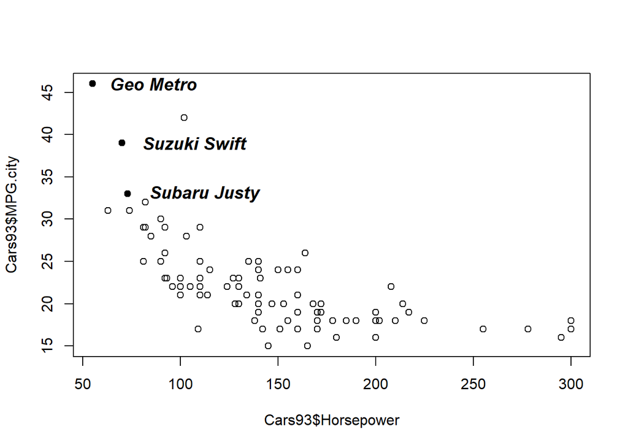

```r
# Plot MPG.city vs. Horsepower as open circles
plot(Cars93$Horsepower, Cars93$MPG.city,
     pch = 1)

# Create index3, pointing to 3-cylinder cars
index3 <- which(Cars93$Cylinders ==3)

# Highlight 3-cylinder cars as solid circles
points(Cars93$Horsepower[index3], Cars93$MPG.city[index3],
       pch = 16)

# Add car names, offset from points, with larger bold text
text(Cars93$Horsepower[index3], Cars93$MPG.city[index3],
     labels = Cars93$Make[index3],
     adj = -0.2,
     cex = 1.2,
     font = 4)
```

```r
names(Cars93)
```

```
##  [1] "Manufacturer"       "Model"              "Type"
##  [4] "Min.Price"          "Price"              "Max.Price"
##  [7] "MPG.city"           "MPG.highway"        "AirBags"
## [10] "DriveTrain"         "Cylinders"          "EngineSize"
## [13] "Horsepower"         "RPM"                "Rev.per.mile"
## [16] "Man.trans.avail"    "Fuel.tank.capacity" "Passengers"
## [19] "Length"             "Wheelbase"          "Width"
## [22] "Turn.circle"        "Rear.seat.room"     "Luggage.room"
## [25] "Weight"             "Origin"             "Make"
```

### Rotating text with the srt argument

In addition to the optional arguments used in the previous exercises, the text() function also supports a number of other optional arguments that can be used to enhance the text. This exercise uses the cex argument to reduce the text size and introduces two new arguments. The first is the col argument that specifies the color used to display the text, and the second is the srt argument that allows us to rotate the text.

Color has been used in several of the previous exercises to specify point colors, and the effective use of color is discussed further in Chapter 5. One of the points of this exercise is to show that the specification of text color with the text() function is essentially the same as the specification of point color with the plot() function. As a specific example, setting col = “green” in the text() function causes the text to appear in green. If col is not specified, the text appears in the default color set by the par() function, which is typically black.

The srt parameter allows us to rotate the text through an angle specified in degrees. The typical default value (set by the par() function) is 0, causing the text to appear horizontally, reading from left to right. Specifying srt = 90 causes the text to be rotated 90 degrees counter-clockwise so that it reads from bottom to top instead of left to right.

Create a scatterplot of Gas vs. Temp from the whiteside data frame, as solid triangles. Use the which() function to create a vector indexB that points to all data observations with Insul having the value “Before”. Use the which() function to create a vector indexA that points to all data observations with Insul having the value “After”. Use the text() function to overlay the text “Before” on the appropriate points, in blue, rotated 30 degrees, reducing the text size to 80 percent of the default. Use the text() function to overlay the text “After” on the appropriate points, in red, rotated -20 degrees, reducing the text size to 80 percent of the default.

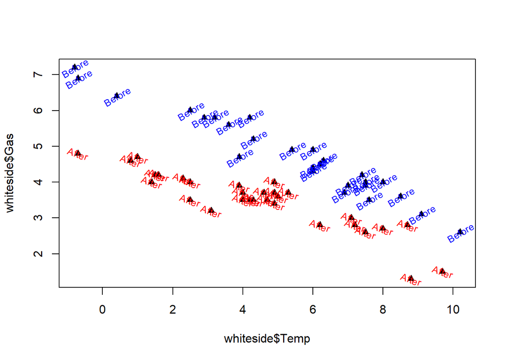

```r
# Plot Gas vs. Temp as solid triangles
plot(whiteside$Temp, whiteside$Gas,
     pch = 17)

# Create indexB, pointing to "Before" data
indexB <- which(whiteside$Insul == "Before")

# Create indexA, pointing to "After" data
indexA <- which(whiteside$Insul == "After")

# Add "Before" text in blue, rotated 30 degrees, 80% size
text(x = whiteside$Temp[indexB], y = whiteside$Gas[indexB],
     labels = "Before", col = "blue", srt = 30, cex = 0.8)

# Add "After" text in red, rotated -20 degrees, 80% size
text(x = whiteside$Temp[indexA], y = whiteside$Gas[indexA],
     labels = "After", col = "red", srt = -20, cex = 0.8)
```

### Adding or modifying other plot details

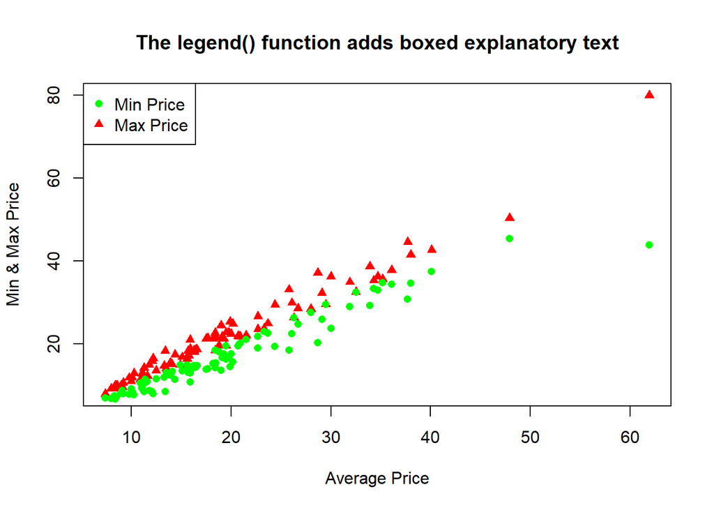

```r
library(MASS)
plot(Cars93$Price, Cars93$Max.Price,
     pch = 17,
     col = "red",
     xlab = "Average Price",
     ylab = "Min & Max Price")
points(Cars93$Price, Cars93$Min.Price,
       pch = 16,
       col = "green")
legend(x = "topleft",
       pch = c(16, 17),
       col = c("green", "red"),
       legend = c("Min Price", "Max Price"))
title("The legend() function adds boxed explanatory text")
```

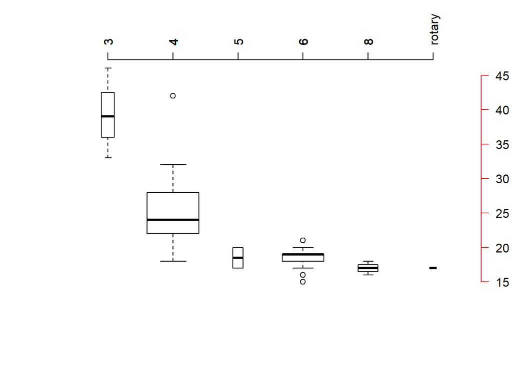

```r
library(MASS)
boxplot(MPG.city ~ Cylinders, data = Cars93,
        varwidth = TRUE,
        axes = FALSE)
axis(side = 3,
     at = Cars93$Cylinders,
     labels = as.character(Cars93$Cylinders),
     las = 2)
axis(side = 4,
     col = "red",
     las = 1)
```

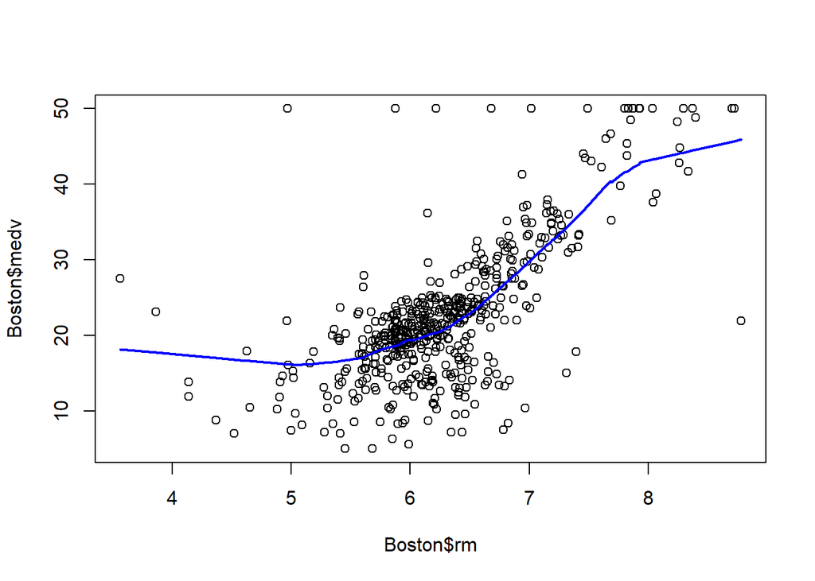

```r
library(MASS)
plot(Boston$rm, Boston$medv)
trend <- supsmu(Boston$rm, Boston$medv)
lines(trend,
      lwd = 2,
      col = "blue")
```

### Using the legend() function

The video described and illustrated the use of the legend() function to add explanatory text to a plot.

This exercise asks you to first create a scatterplot and then use this function to add explanatory text for the point shapes that identify two different data subsets.

Set up a scatterplot of Gas vs. Temp from the whiteside data frame using type = “n” option in the plot() call. Label the x-axis “Outside temperature” by specifying the xlab argument and the y-axis “Heating gas consumption” by specifying the ylab argument. Use the which() function to create a vector indexB that points to all data observations with Insul having the value “Before”. Use the which() function to create a vector indexA that points to all data observations with Insul having the value “After”. Using the points() function, add the “Before” points to the plot, represented as solid triangles. Using the points() function, add the “After” points to the plot, represented as open circles. Using the legend() function, add a legend in the upper right corner of the plot with the names “Before” and “After” and the appropriate point shapes indicated.

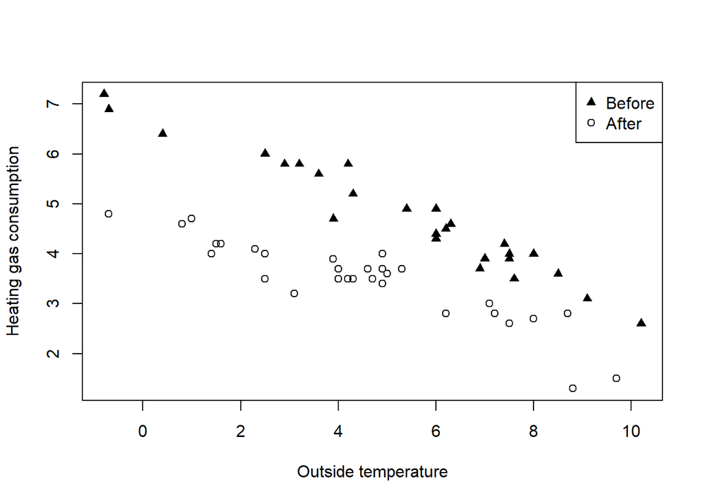

```r
plot(whiteside$Temp, whiteside$Gas,
     type = "n",
     xlab = "Outside temperature",
     ylab = "Heating gas consumption")

indexB <- which(whiteside$Insul == "Before")
indexA <- which(whiteside$Insul == "After")

points(whiteside$Temp[indexB], whiteside$Gas[indexB],
       pch = 17)
points(whiteside$Temp[indexA], whiteside$Gas[indexA],
       pch = 1)
legend(x = "topright",
       pch = c(17, 1),
       legend = c("Before", "After")
)
```

### Adding custom axes with the axis() function

Typical base graphics functions like boxplot() provide x- and y-axes by default, with a label for the x-axis below the plot and one for the y-axis label to the left of the plot. These labels are generated automatically from the variable names used to generate the plot. Sometimes, we want to provide our own axes labels, and R makes this possible in two steps: first, we suppress the default axes when we create the plot by specifying axes = FALSE; then, we call the low-level graphics function axis() to create the axes we want.

In this exercise, you’re asked to create your own labels using the axis() function with the side, at, and labels arguments. The side argument tells the function which axis to create: a value of 1 adds an axis below the plot; 2 adds an axis on the left; 3 puts it across the top; and 4 puts it on the right side. The second argument, at, is a vector that defines points where tick-marks will be drawn on the axis. The third argument, labels, is a vector that defines labels at each of these tick-marks.

One example of a boxplot with custom axes was presented in the video. This exercise asks you to create another example showing the relationship between the sugars variable and the shelf variable from the UScereal data frame in the MASS package.

Use the boxplot() function to create a boxplot of sugars vs. shelf from the UScereal data frame in the MASS package, with axes suppressed. Use the axis() function with the side parameter specified to add a y-axis label to the left of the box plot showing the range of sugars values. In your second call to axis(), add an x-axis label on the bottom side and specify the at parameter to add tick-marks at the numerical shelf values labelled 1, 2, and 3. In your third call to axis(), add another x-axis label at the top and specify the labels parameter to show the physical shelf locations (“floor”, “middle”, “top”).

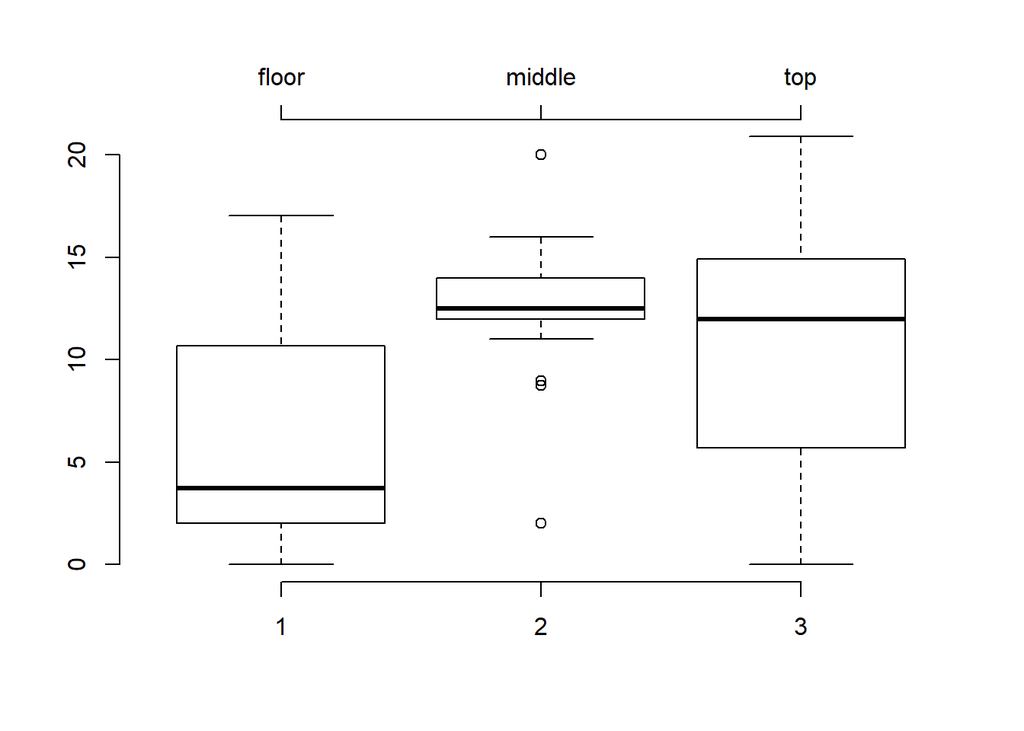

```r
# Create a boxplot of sugars by shelf value, without axes
boxplot(sugars ~ shelf,
        data = UScereal,
        axes = FALSE)

# Add a default y-axis to the left of the boxplot
axis(side = 2)

# Add an x-axis below the plot, labelled 1, 2, and 3
axis(side = 1,
     at = c(1, 2, 3))

# Add a second x-axis above the plot
axis(side = 3,
     at = c(1, 2, 3),
     labels = c("floor", "middle", "top")
     )
```

### Using the supsmu() function to add smooth trend curves

As we saw in the video, some scatterplots exhibit fairly obvious trends that are not linear. In such cases, we may want to add a curved trend line that highlights this behavior of the data and the supsmu() function represents one way of doing this.

To use this function, we need to specify values for the required arguments x and y, but it also has a number of optional arguments. Here, we consider the optional bass argument, which controls the degree of smoothness in the resulting trend curve. The default value is 0, but specifying larger values (up to a maximum of 10) results in a smoother curve. This exercise asks you to use the supsmu() function to add two trend lines to a scatterplot, one using the default parameters and the other with increased smoothness.

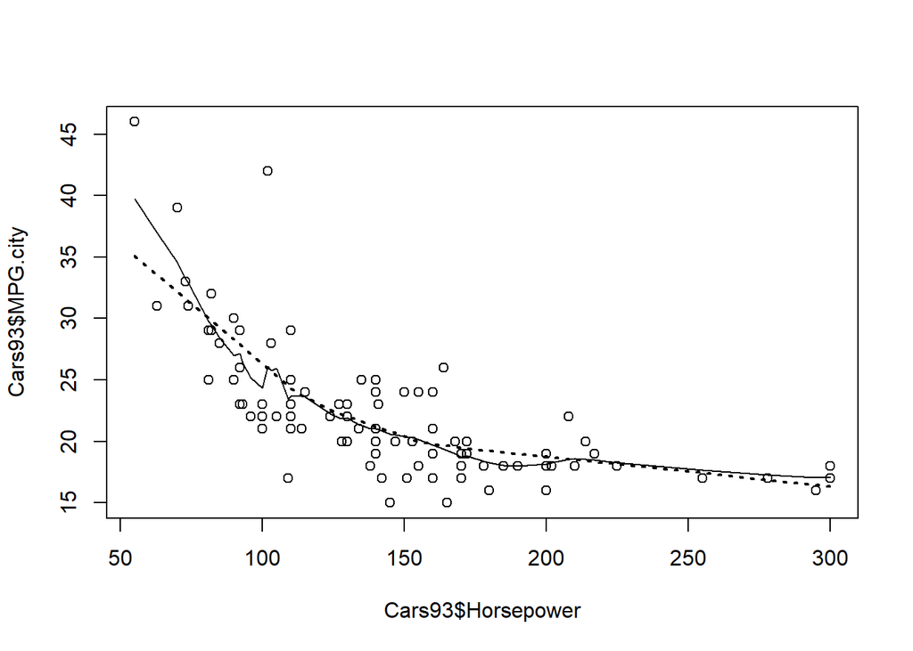

```r
plot(Cars93$Horsepower, Cars93$MPG.city)
trend1 <- supsmu(Cars93$Horsepower, Cars93$MPG.city)
lines(trend1)
trend2 <- supsmu(Cars93$Horsepower, Cars93$MPG.city,
                 bass = 10)
lines(trend2,
      lwd = 2,
      lty = 3)
```

## How Much is Too Much

### Managing Visual Complexity

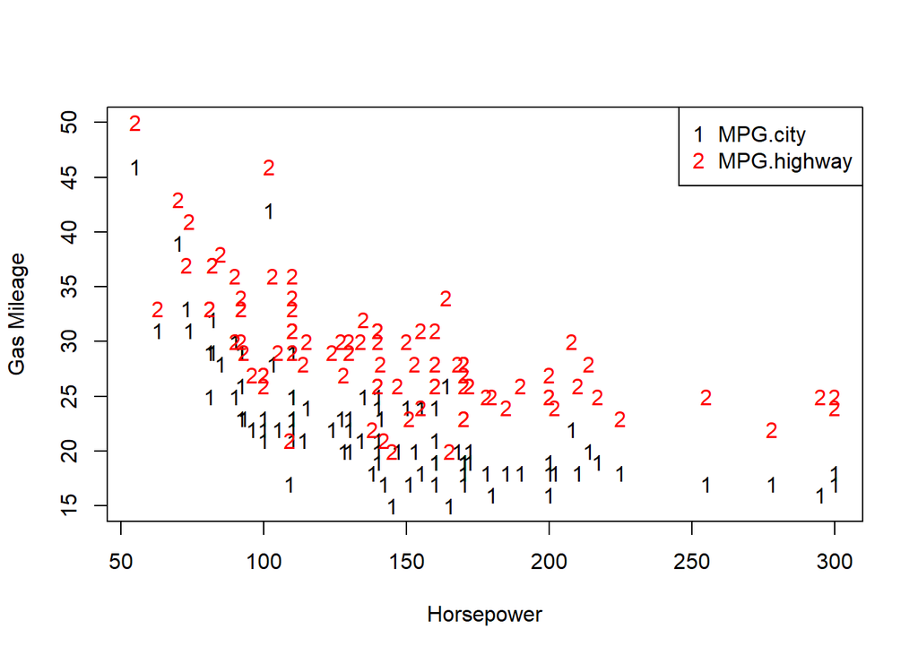

```r
library(MASS)
matplot(Cars93$Horsepower, Cars93[, c("MPG.city", "MPG.highway")],
        xlab = "Horsepower",
        ylab = "Gas Mileage")
legend("topright",
       pch = c("1", "2"),
       col = c("black", "red"),
       legend = c("MPG.city", "MPG.highway")
)
```

### Too much is too much

The first example presented in Chapter 1 applied the plot() function to a data frame, yielding an array of scatterplots with one for each pair of columns in the data frame. Thus, the number of plots in this array is equal to the square of the number of columns in the data frame.

This means that if we apply the plot() function to a data frame with many columns, we will generate an enormous array of scatterplots, each of which will be too small to be useful. The purpose of this exercise is to provide a memorable example.

Applying the plot() function to a data frame with k columns will create a k by k array of scatterplots.

Use the ncol() function to compute the number of plots in this array for the Cars93 data frame. Just print the result to the console. Call plot() on Cars93 to generate the scatterplot array. Can you verify that your calculation was correct?

```r
# Compute the number of plots to be displayed
ncol(Cars93)^2
```

```
## [1] 729
```

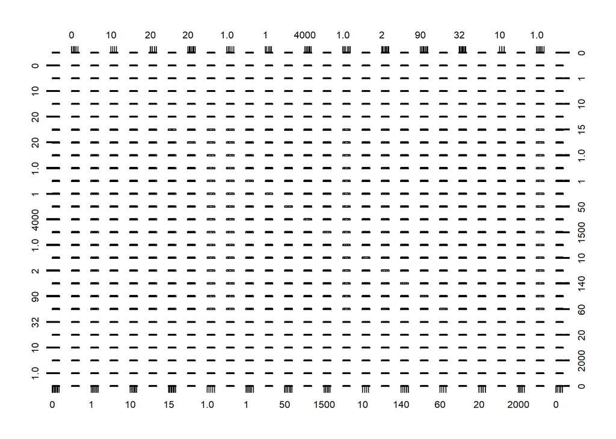

```r
# Plot the array of scatterplots
plot(Cars93)
```

### Deciding how many scatterplots is too many

As noted in the video, the matplot() function can be used to easily generate a plot with several scatterplots on the same set of axes. By default, the points in these scatterplots are represented by the numbers 1 through n, where n is the total number of scatterplots included, but most of the options available with the plot() function are also possible by specifying the appropriate arguments.

This exercise asks you to set up a plot array with four of these multiple scatterplot displays, each including one more scatterplot than the previous one. The point of this exercise is to encourage you to judge for yourself how many scatterplots is too many?.

Run the first line of sample code provided to construct a character vector called keep_vars that names six variables from the UScereal data frame. Using this vector of variable names, extract the data frame df containing only these variables from the UScereal data frame. Use the par() function to set up the mfrow parameter to generate a two-by-two plot array. Use the matplot() function to construct a two-scatterplot display of protein and fat versus calories. Give this plot the title “Two scatterplots” using the title() function. Label the x-axis “calories” and the y-axis “” to get rid of the default y-axis label. protein, fat and fibre versus calories. Give this plot the title “Three scatterplots”. Similarly, label the x-axis “calories” and the y-axis “”. protein, fat, fibre and carbo versus calories. Give this plot the title “Four scatterplots”. Again, label the x-axis “calories” and the y-axis “”. protein, fat, fibre, carbo, and sugars versus calories. Give this plot the title “Five scatterplots”. Be sure to label the x-axis “calories” and the y-axis “” again.

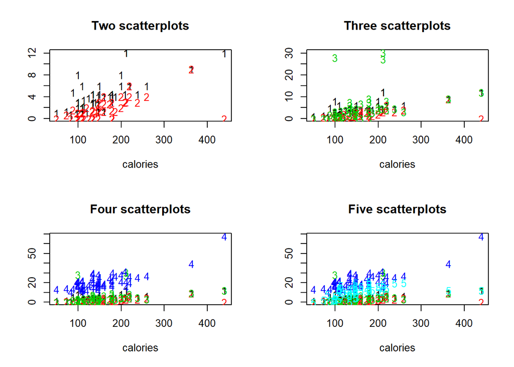

```r
# Construct the vector keep_vars
keep_vars <- c("calories", "protein", "fat",
               "fibre", "carbo", "sugars")

# Use keep_vars to extract the desired subset of UScereal
df <- UScereal[, keep_vars]

# Set up a two-by-two plot array
par(mfrow = c(2, 2))

# Use matplot() to generate an array of two scatterplots
matplot(df$calories, df[, c("protein", "fat")],
        xlab = "calories",
        ylab = "")

# Add a title
title("Two scatterplots")

# Use matplot() to generate an array of three scatterplots
matplot(df$calories, df[, c("protein", "fat", "fibre")],
        xlab = "calories",
        ylab = "")

# Add a title
title("Three scatterplots")

# Use matplot() to generate an array of four scatterplots
matplot(df$calories, df[, c("protein", "fat", "fibre", "carbo")],
        xlab = "calories",
        ylab = "")

# Add a title
title("Four scatterplots")

# Use matplot() to generate an array of five scatterplots
matplot(df$calories, df[, c("protein", "fat", "fibre", "carbo", "sugars")],
        xlab = "calories",
        ylab = "")

# Add a title
title("Five scatterplots")
```

### How many words is too many?

The main point of the previous two exercises has been to show that scatterplot arrays lose their utility if they are allowed to become too complex, either including too many plots, or attempting to include too many scatterplots on one set of axes. More generally, any data visualization loses its utility if it becomes too complex.

This exercise asks you to consider this problem with wordclouds, displays that present words in varying sizes depending on their frequency. That is, more frequent words appear larger in the display, while rarer words appear in a smaller font.

In R, wordclouds are easy to generate with the wordcloud() function in the wordcloud package. This function is called with a character vector of words, and a second numerical vector giving the number of times each word appears in the collection used to generate the wordcloud.

Two other useful arguments for this function are scale and min.freq. The scale argument is a two-component numerical vector giving the relative size of the largest word in the display and that of the smallest word. The wordcloud only includes those words that occur at least min.freq times in the collection and the default value for this argument is 3.

The wordcloud package is already loaded in your workspace.

Use the table() function to create the variable mfr_table that tabulates the number of times each level of the Manufacturer variable appears in the Cars93 data frame. Use the wordcloud() function to display this manufacturer data, setting the scale argument to c(2, 0.25) to make the wordcloud fit in the display window. By default, the wordcloud() function shows only those words that appear 3 or more times. Use the min.freq argument to obtain a display with all Manufacturer values in the wordcloud. Use the table() function to create the variable model_table that tabulates the number of times each level of the Model variable appears in the Cars93 data frame. Use the wordcloud() function with the scale argument set to c(0.75, 0.25) and the min.freq argument set to display all Model values. Use the zoom feature in the ‘Plots’ window to see this wordcloud more clearly. Does it convey useful information?

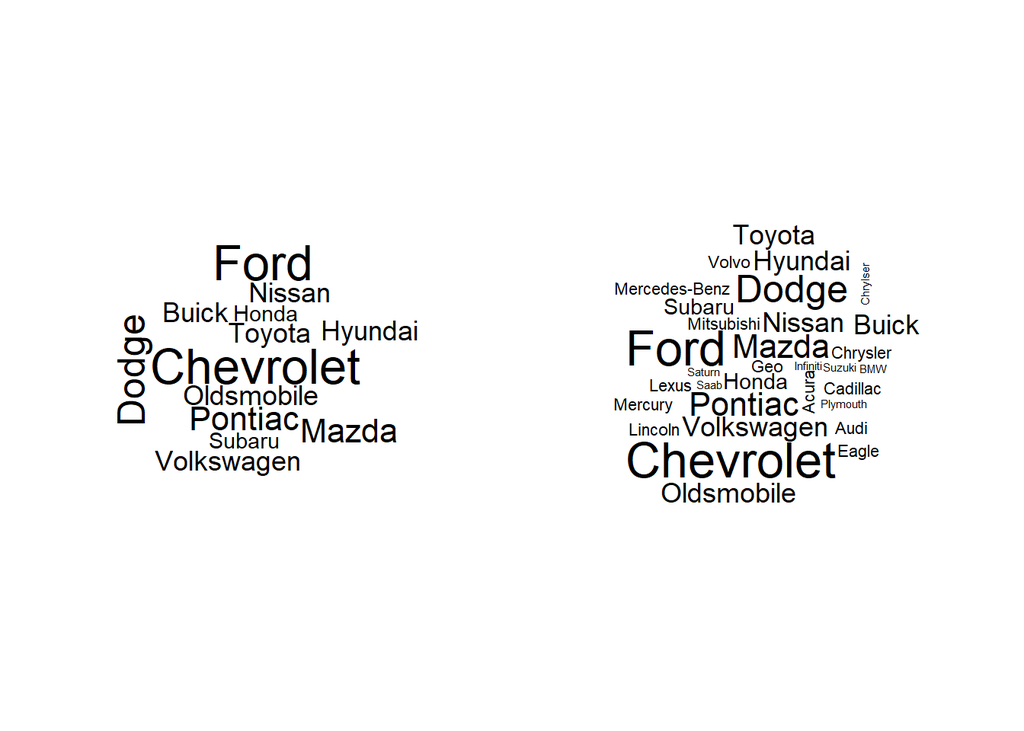

```r
library(wordcloud)
library(tidyverse)
mfrow(1, 2)
mfr_table <- table(Cars93$Manufacturer)

wordcloud(words = names(mfr_table),
          freq = as.numeric(mfr_table),
          scale = c(2, 0.25)
          )

wordcloud(words = names(mfr_table),
          freq = as.numeric(mfr_table),
          scale = c(2, 0.25),
          min.freq = 1
          )
```

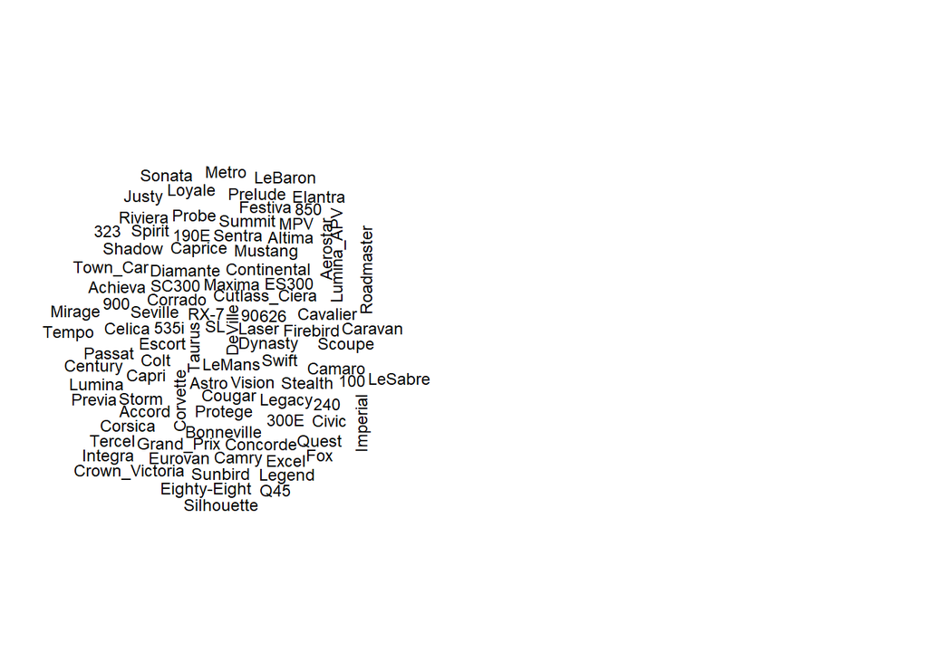

```r
model_table <- table(Cars93$Model)

wordcloud(words = names(model_table),
          freq = as.numeric(model_table),
          scale = c(0.75, 0.25),
          min.freq = 1
          )
```

### Useful Multiple Plot Arrays

### The Anscombe quartet

This exercise and the next one are based on the Anscombe quartet, a collection of four datasets that appear to be essentially identical on the basis of simple summary statistics like means and standard deviations. For example, the mean x-values for these datasets are identical to three digits, while the mean y-values differ only in the third digit.

In spite of these apparent similarities, the behavior of the four datasets is quite different and this becomes immediately apparent when we plot them.

Use the par() function to set up a two-by-two plot array. Using plot(), create 4 separate plots from the anscombe data frame: y1 vs. x1 y2 vs. x2 y3 vs. x3 y4 vs. x4

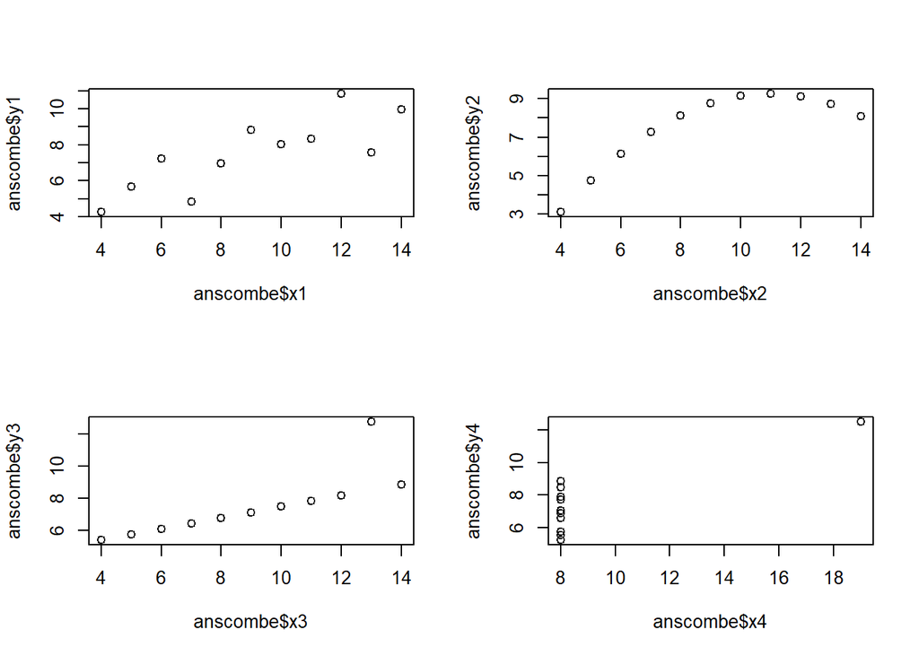

```r
data("anscombe")
# Set up a two-by-two plot array
par(mfrow = c(2, 2))

# Plot y1 vs. x1
plot(anscombe$x1, anscombe$y1)

# Plot y2 vs. x2
plot(anscombe$x2, anscombe$y2)

# Plot y3 vs. x3
plot(anscombe$x3, anscombe$y3)

# Plot y4 vs. x4
plot(anscombe$x4, anscombe$y4)
```

### The utility of common scaling and individual titles

The plots you generated in the previous exercise showed that the four Anscombe quartet datasets have very different appearances, but a careful examination of these plots reveals that they exhibit different ranges of x and y values.

The point of this exercise is to illustrate how much more clearly we can see the differences in these datasets if we plot all of them with the same x and y ranges. This exercise also illustrates the utility of improving the x- and y-axis labels and of adding informative plot titles.

Examine the range of x and y values from the previous four plots to determine a common range that covers the ranges of all four of these plots. Use integer values to keep things simple. Set up a two-by-two plot array using the par() function. Plot the y1 variable against the x1 variable using these common ranges, with x-axis label “x value” and y-axis label “y value”, and use the main argument to add the title “First dataset”. Repeat for the other three Anscombe data pairs, adding the appropriate titles.

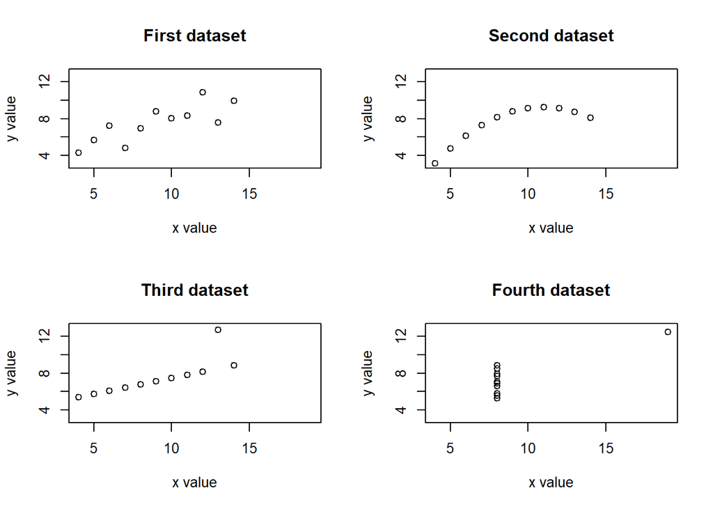

```r
# Define common x and y limits for the four plots
xmin <- 4
xmax <- 19
ymin <- 3
ymax <- 13

# Set up a two-by-two plot array
par(mfrow = c(2, 2))

# Plot y1 vs. x1 with common x and y limits, labels & title
plot(anscombe$x1, anscombe$y1,
     xlim = c(xmin, xmax),
     ylim = c(ymin, ymax),
     xlab = "x value", ylab = "y value",
     main = "First dataset")

# Do the same for the y2 vs. x2 plot
plot(anscombe$x2, anscombe$y2,
     xlim = c(xmin, xmax),
     ylim = c(ymin, ymax),
     xlab = "x value", ylab = "y value",
     main = "Second dataset")

# Do the same for the y3 vs. x3 plot
plot(anscombe$x3, anscombe$y3,
     xlim = c(xmin, xmax),
     ylim = c(ymin, ymax),
     xlab = "x value", ylab = "y value",
     main = "Third dataset")

# Do the same for the y4 vs. x4 plot
plot(anscombe$x4, anscombe$y4,
     xlim = c(xmin, xmax),
     ylim = c(ymin, ymax),
     xlab = "x value", ylab = "y value",
     main = "Fourth dataset")
```

### Using multiple plots to give multiple views of a dataset

As noted in the video, another useful application of multiple plot arrays besides comparison is presenting multiple related views of the same dataset.

This exercise illustrates this idea, giving four views of the same dataset: a plot of the raw data values themselves, a histogram of these data values, a density plot, and a normal QQ-plot.

Note that the MASS and car packages have been pre-loaded, making the geyser data and the truehist() and qqPlot() fuctions available for your use. Use the par() function to set the mfrow parameter for a two-by-two plot array. In the upper left, use the plot() function to show the values of the duration variable from the geyser dataset, using the main argument to specify the plot title as “Raw data”. In the upper right, use the truehist() function to generate a histogram of the duration data, using the main argument to give this plot the title “Histogram”. In the lower left, use the plot() and density() functions to display the density of the duration values, using the main argument to give this plot the title “Density”. In the lower right, use the qqPlot() function from the car package to display a normal QQ-plot of the duration data, using the main argument to give this plot the title “QQ-plot”.

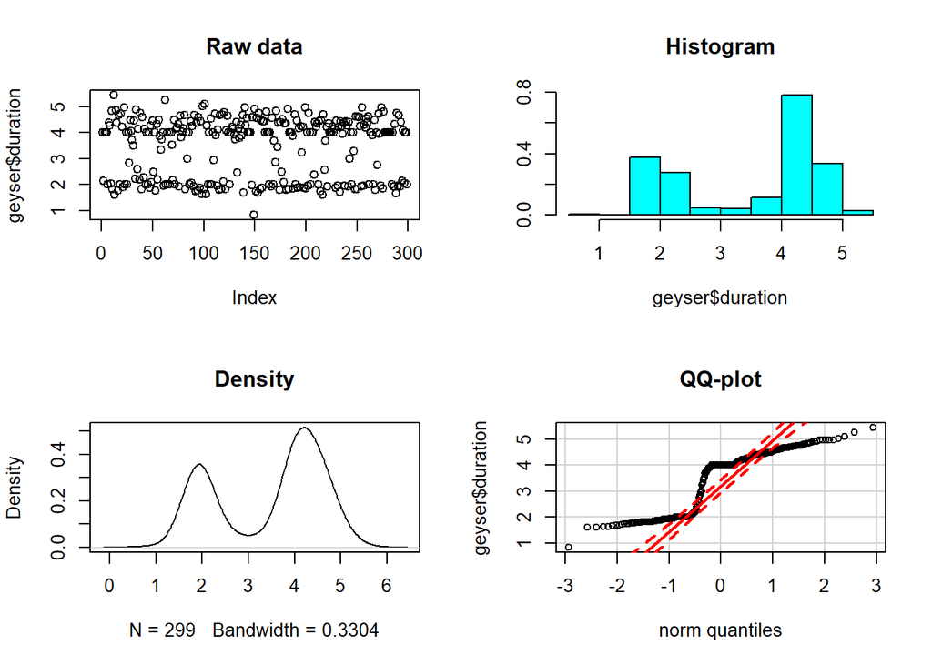

```r
rm(list = ls())
library(MASS)
library(car)
# Set up a two-by-two plot array
par(mfrow = c(2, 2))

# Plot the raw duration data
plot(geyser$duration,
     main = "Raw data")

# Plot the normalized histogram of the duration data
truehist(geyser$duration,
         main = "Histogram")

# Plot the density of the duration data
plot(density(geyser$duration),
     main = "Density")

# Construct the normal QQ-plot of the duration data
qqPlot(geyser$duration,
       main = "QQ-plot")
```

### layout to create plot arrays

```r
#construct the layout matrix
rowA <- c(1, 1, 1)
rowB <- c(2, 0, 3)
layoutVectorClass <- c(rowA, rowA, rowB)
layoutMatrixClass <- matrix(layoutVectorClass, byrow = TRUE, nrow = 3)
layoutMatrixClass
```

```
##      [,1] [,2] [,3]
## [1,]    1    1    1
## [2,]    1    1    1
## [3,]    2    0    3
```

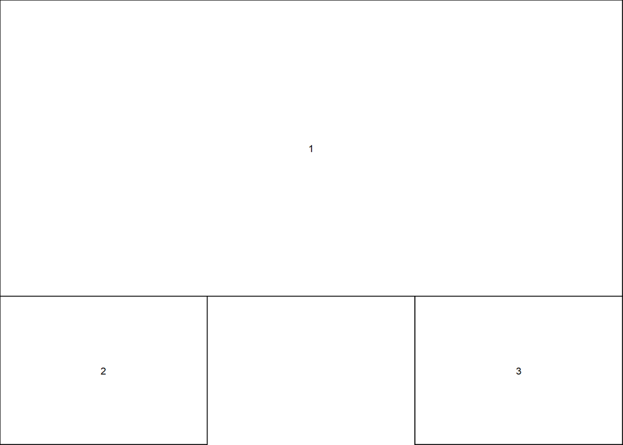

```r
#use previously constructed matrix
layout(layoutMatrixClass)
#layout.show displays where each plot will be placed
layout.show(n = 3)
```

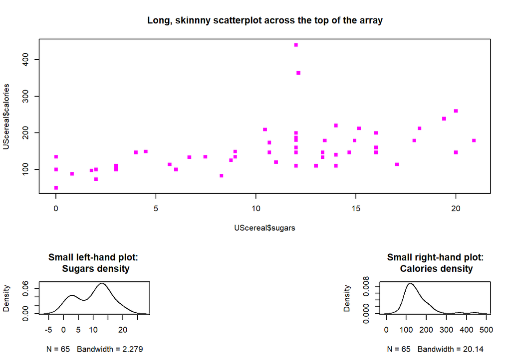

```r
plot(UScereal$sugars,
     UScereal$calories,
     pch = 15,
     col = "magenta",
     main = "Long, skinnny scatterplot across the top of the array")

plot(density(UScereal$sugars),
     main = "Small left-hand plot: \n Sugars density")

plot(density(UScereal$calories),
     main = "Small right-hand plot:\n Calories density")
```

### Constructing and displaying layout matrices

The video illustrated how to set up a layout matrix to be used with the layout() function in creating a plot array. You can think of the layout matrix as the plot pane, where a 0 represents empty space and other numbers represent the plot number, which is determined by the sequence of visualization function calls. For example, a 1 in the layout matrix refers to the visualization that was first called, a 2 refers to the plot of the second visualization call, etc. This exercise asks you to create your own 3 x 2 layout matrix, using the c() function to concatenate numbers into vectors that will form the rows of the matrix.

You will then use the matrix() function to convert these rows into a matrix and apply the layout() function to set up the desired plot array. The convenience function layout.show() can then be used to verify that the plot array has the shape you want.

As reference, feel free to use the slides from the video, which you can access by clicking on the “Slides” tab next to the “R Console” tab. Pay close attention to the example layout matrix and the resulting plot array.

Using the matrix() function, create a matrix called layoutMatrix with three rows and two columns: the first row designates an empty plot to the left and plot 1 to the right. the second row designates plot 2 to the left and an empty plot to the right. the third row designates an empty plot to the left and plot 3 to the right. Use the layout() function to set up the desired plot array. Use the layout.show() function to show the arrangement of all three plots.

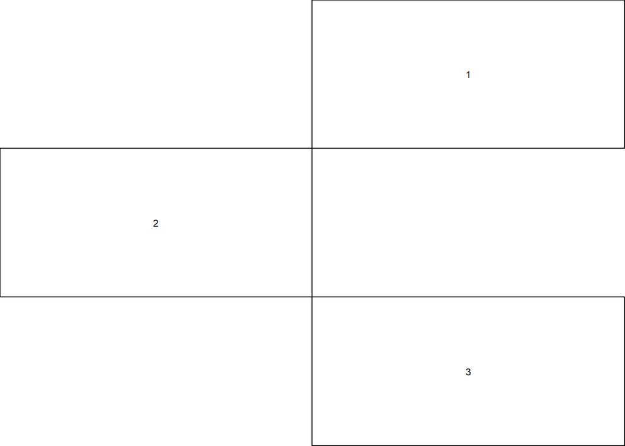

```r
# Use the matrix function to create a matrix with three rows and two columns
layoutMatrix <- matrix(
  c(
    0, 1,
    2, 0,
    0, 3
  ),
  byrow = TRUE,
  nrow = 3
)

# Call the layout() function to set up the plot array
layout(layoutMatrix)

# Show where the three plots will go
layout.show(n = 3)
```

### Creating a triangular array of plots

The previous exercise asked you to create a plot array using the layout() function. Recall the layout matrix from the previous exercise:

layoutMatrix [,1] [,2] [1,] 0 1 [2,] 2 0 [3,] 0 3 This exercise asks you to use this array to give three different views of the whiteside data frame.

The primary motivation for this exercise is that it is not possible to construct a plot array in this format using the mfrow parameter, since the array is not rectangular.

The layout matrix you set up in the previous is available in your workspace as layoutMatrix. The whiteside data frame is already available in your workspace as well.

Call the layout() function on layoutMatrix to set up the plot array. Construct a vector indexB that points to only those records with the Insul value “Before” and a vector indexA that points to only those records with the Insul value “After”. Plot the Gas versus Temp values from the indexB data in the upper right plot in your array, using the y-axis limits c(0, 8). Give this plot the title “Before data only”. Plot the Gas versus Temp values from the complete dataset in the center left plot, using the same y-axis limits as the first plot. Give this plot the title “Complete dataset”. Plot the Gas versus Temp values from the indexA data in the lower right plot, again using the same y-axis limits. Give this plot the title “After data only”.

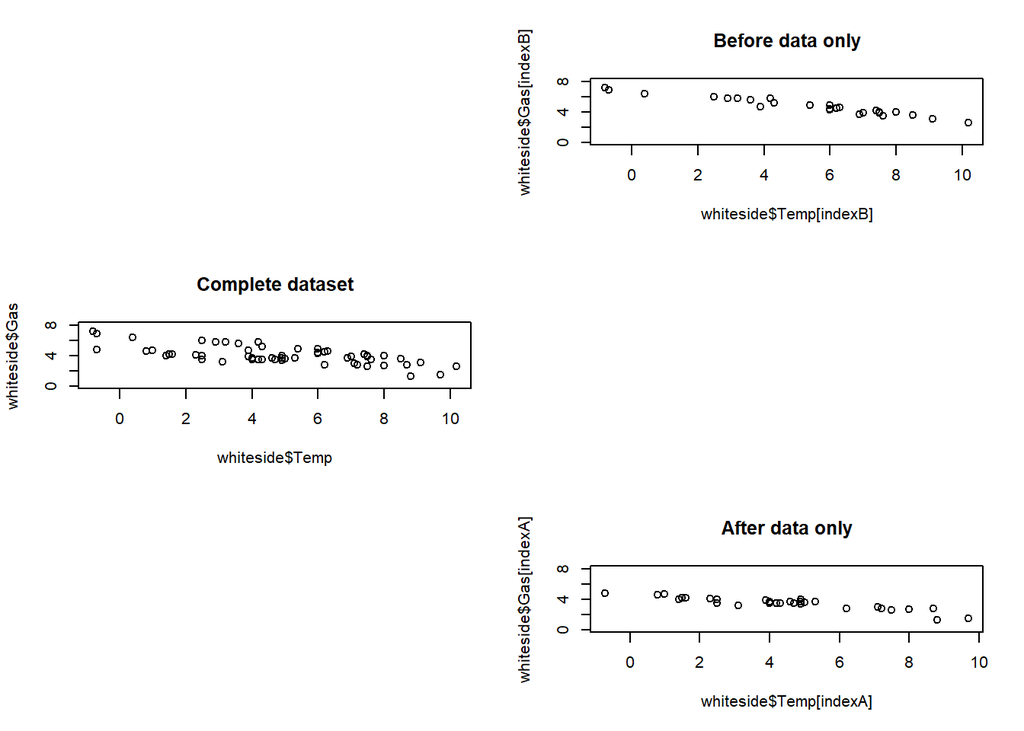

```r
# Set up the plot array
layout(layoutMatrix)

# Construct vectors indexB and indexA
indexB <- which(whiteside$Insul == "Before")
indexA <- which(whiteside$Insul == "After")

# Create plot 1 and add title
plot(whiteside$Temp[indexB],
     whiteside$Gas[indexB],
     ylim = c(0, 8)
     )
title("Before data only")

# Create plot 2 and add title
plot(whiteside$Temp,
     whiteside$Gas,
     ylim = c(0, 8)
     )
title("Complete dataset")

# Create plot 3 and add title
plot(whiteside$Temp[indexA],
     whiteside$Gas[indexA],
     ylim = c(0, 8)
     )
title("After data only")
```

### Creating arrays with different sized plots

Besides creating non-rectangular arrays, the layout() function can be used to create plot arrays with different sized component plots – something else that is not possible by setting the par() function’s mfrow parameter.

This exercise illustrates the point, asking you to create a standard scatterplot of the zn versus rad variables from the Boston data frame as a smaller plot in the upper left, with a larger sunflower plot of the same data in the lower right.

The Boston data frame in the MASS package is already available in your workspace.

Using the c() function: Create the three-element vector row1 with values (1, 0, 0). Create the three-element vector row2 with values (0, 2, 2). Combine the first vector with two copies of the second vector into layoutVector, a vector of length 9. Using the matrix() function, convert layoutVector into the 3-by-3 matrix layoutMatrix whose first row is row1 and whose second and third rows are row2. Use the layout() function with layoutMatrix to configure a two-element plot array. In the first (smaller) plot, create a standard scatterplot of the zn variable versus the rad variable from the Boston data frame. In the second (larger) plot, create a sunflower plot using the sunflowerplot() function and the same variables.

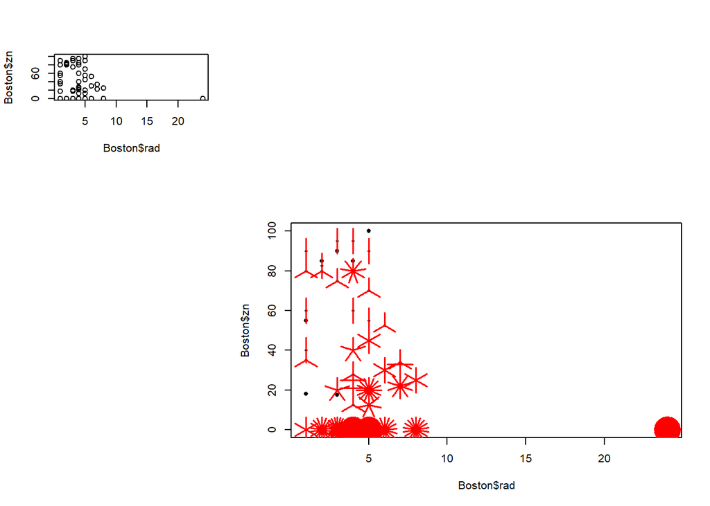

```r
# Create row1, row2, and layoutVector
row1 <- c(1, 0, 0)
row2 <- c(0, 2, 2)
layoutVector <- c(row1, row2, row2)

# Convert layoutVector into layoutMatrix
layoutMatrix <- matrix(layoutVector,
                       byrow = TRUE,
                       nrow = 3)

# Set up the plot array
layout(layoutMatrix)

# Plot scatterplot
plot(Boston$rad, Boston$zn)

# Plot sunflower plot
sunflowerplot(Boston$rad, Boston$zn)
```

## Advanced Plot Customization and Beyond